# LifeGenMon Fagus SNP analysis

Nikos Tourvas

2019-06-30

# Data filtering

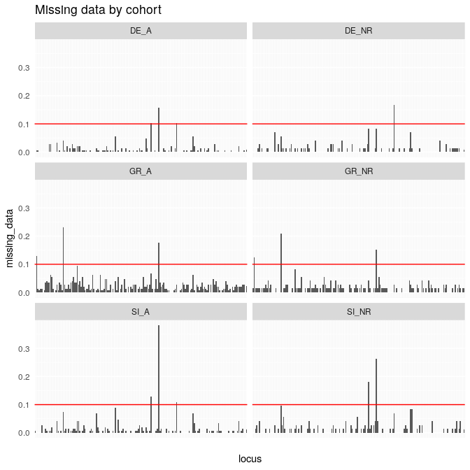

Some SNP loci exhibit high levels of missing data for some cohorts only. Maybe leverage this information per Country / Cohort basis?

### Percent (%) of missing data by pop

| DE_A | DE_NR | GR_A | GR_NR | SI_A | SI_NR |
| --- | --- | --- | --- | --- | --- |
| 0.78 | 0.87 | 2.3 | 1.56 | 1.16 | 1.26 |

### How many loci are biallelic?

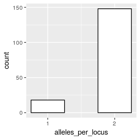

| alleles per locus | occurences | occurences (%) |
| --- | --- | --- |
| 1 | 18 | 10.84 |
| 2 | 148 | 89.16 |

### Data filtering thresholds

```
[1] "SNP loci: 10 % missing data across populations"
[1] "Individuals: 10 % missing data"
[1] "SNP loci with minor allele frequency < 0.00775193798449612"
```

MAF corresponds to 5 samples (i.e. an allele has to be present in 5 or more individuals, or else it is discarded)

### Data set details after data filtering:

```
[1] "645 individuals and 139 loci"
```

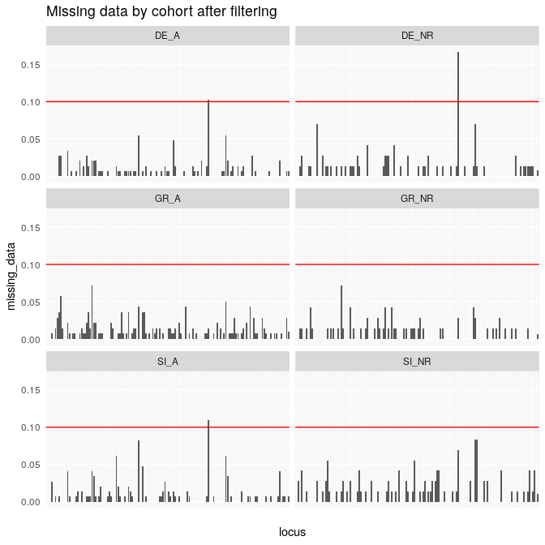

The filters applied, reduce the data set to loci with missing data < 10% overall. As shown above, loci within cohorts might exceed this limit.

# Summary statistics

|  | N | na | ne | Ho | uHe | Fis |
| --- | --- | --- | --- | --- | --- | --- |
| DE_A | 146 | 1.971 | 1.453 | 0.272 | 0.273 | 0.011 |
| DE_NR | 72 | 1.957 | 1.455 | 0.282 | 0.272 | -0.019 |
| GR_A | 139 | 1.935 | 1.361 | 0.221 | 0.225 | 0.022 |
| GR_NR | 70 | 1.892 | 1.362 | 0.213 | 0.227 | 0.057 |
| SI_A | 146 | 1.971 | 1.424 | 0.264 | 0.260 | 0.005 |
| SI_NR | 72 | 1.906 | 1.425 | 0.266 | 0.261 | -0.005 |
| Total | 645 | 1.939 | 1.413 | 0.253 | 0.253 | 0.011 |

N: number of individuals  
na: number of alleles per locus  
ne: number of effective alleles  
Ho: observed heterozygosity  
uHe: unbiased expected heterozygosity - gene diversity (Nei 1978)  
Fis: inbreeding coefficient (Nei 1987)

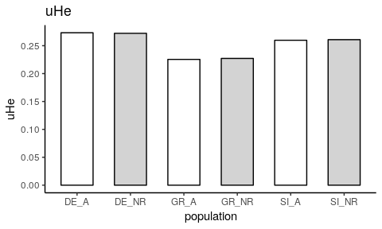

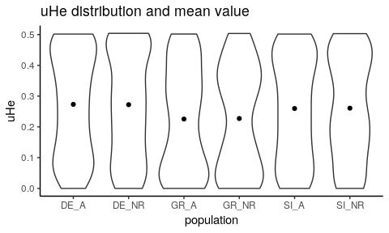

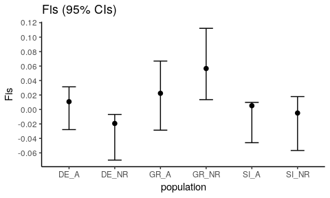

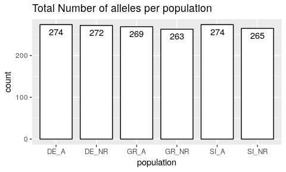

#### Distribution of allele frequencies

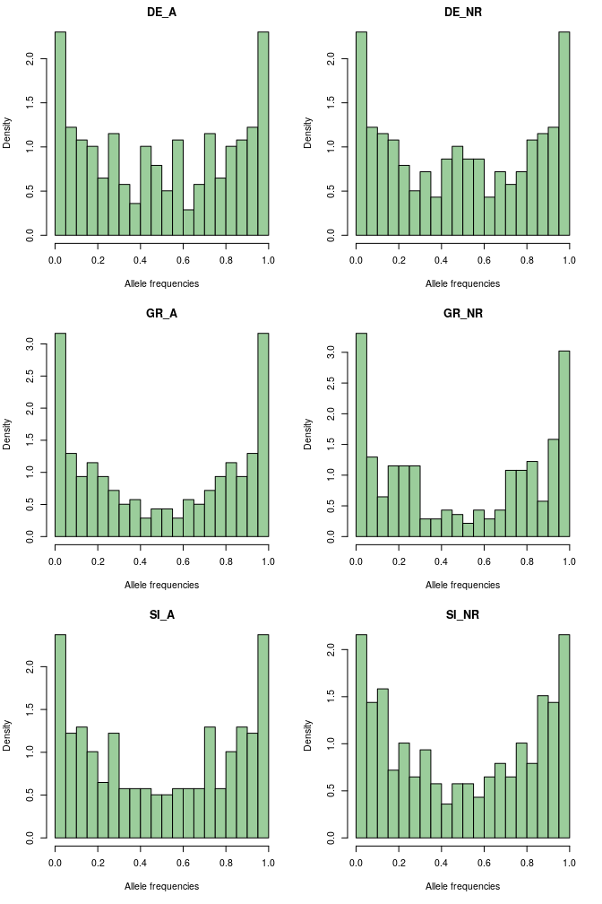

### Private alleles per cohort - level Country/Pop

```
No private alleles detected.
```

### Private alleles per cohort - level Country

| population | allele | count |
| --- | --- | --- |
| DE | 88_2_2_622.G | 11 |
| GR | 88_2_2_622.G | 0 |
| SI | 88_2_2_622.G | 0 |
| DE | 145_2_148.T | 17 |
| GR | 145_2_148.T | 0 |
| SI | 145_2_148.T | 0 |
| DE | 155_3_494.G | 25 |
| GR | 155_3_494.G | 0 |
| SI | 155_3_494.G | 0 |
| DE | 80_748.A | 51 |

[output cut: 2 more lines]

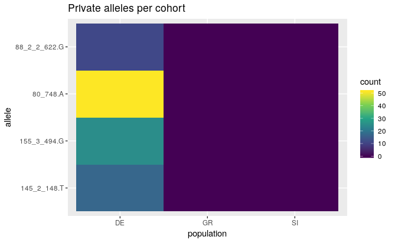

Private alleles per cohort

|  | PA |
| --- | --- |
| DE | 4 |
| GR | 0 |
| SI | 0 |
| Total | 4 |

### LD

```
Column `locus1` joining factors with different levels, coercing to character vectorColumn `locus2` joining factors with different levels, coercing to character vector
```

| locus1 | locus2 |
| --- | --- |
| 14_279 | 14_429 |
| 102_724 | 19_520 |
| 33_299 | 33_422 |
| 58_736 | 58_1005 |
| 60_63 | 60_249 |
| 60_149 | 60_526 |
| 66_228 | 66_411 |
| 130_85 | 130_447 |
| 110_1_293 | 110_1_423 |
| 33_299 | 132_1_391 |

[output cut: 26 more lines]

[output not shown]

| N of pairs of loci with significant LD | population |
| --- | --- |
| 234 | DE |
| 143 | GR |
| 167 | SI |

LD between all pairs of loci was tested seperately for all three cohorts (DE, GR, SI).

The Holm-Bonferroni method was employed to account for multiple testing.

36 pairs of SNPs, exhibited significant LD across all cohorts.

### Hardy - Weinberg equilibrium

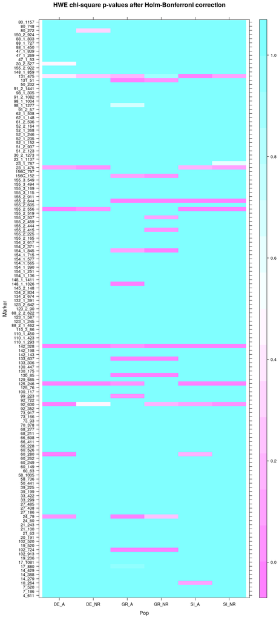

# Genetic Differentiation

### F<sub>ST</sub> (G<sub>ST</sub>) (Nei 1987)

|  | DE_A | DE_NR | GR_A | GR_NR | SI_A |
| --- | --- | --- | --- | --- | --- |
| DE_NR | 0.0064 |  |  |  |  |
| GR_A | 0.1532 | 0.1629 |  |  |  |
| GR_NR | 0.1563 | 0.1651 | 0.0015 |  |  |
| SI_A | 0.0205 | 0.0235 | 0.1605 | 0.1659 |  |
| SI_NR | 0.0264 | 0.0291 | 0.1585 | 0.1643 | 0.0011 |

|  | DE | GR |
| --- | --- | --- |
| GR | 0.1558 |  |
| SI | 0.0217 | 0.1613 |

### Nm based on F<sub>ST</sub> (G<sub>ST</sub>) (Nei 1987)

#### ATTN: Results differ from GenAlEx, as this calculates Nm based on the original F<sub>ST</sub>

| Nm | se |
| --- | --- |
| 54.25 | 26.34 |

### Cavalli-Sforza and Edwards Chord distance (Cavalli Sforza and Edwards 1967)

Cavalli-Sforza and Edwards Chord distance between populations

|  | DE_A | DE_NR | GR_A | GR_NR | SI_A |
| --- | --- | --- | --- | --- | --- |
| DE_NR | 0.0039 |  |  |  |  |
| GR_A | 0.0454 | 0.0496 |  |  |  |
| GR_NR | 0.0468 | 0.0504 | 0.0022 |  |  |
| SI_A | 0.0079 | 0.0108 | 0.0425 | 0.0446 |  |
| SI_NR | 0.0114 | 0.0147 | 0.0427 | 0.0451 | 0.0024 |

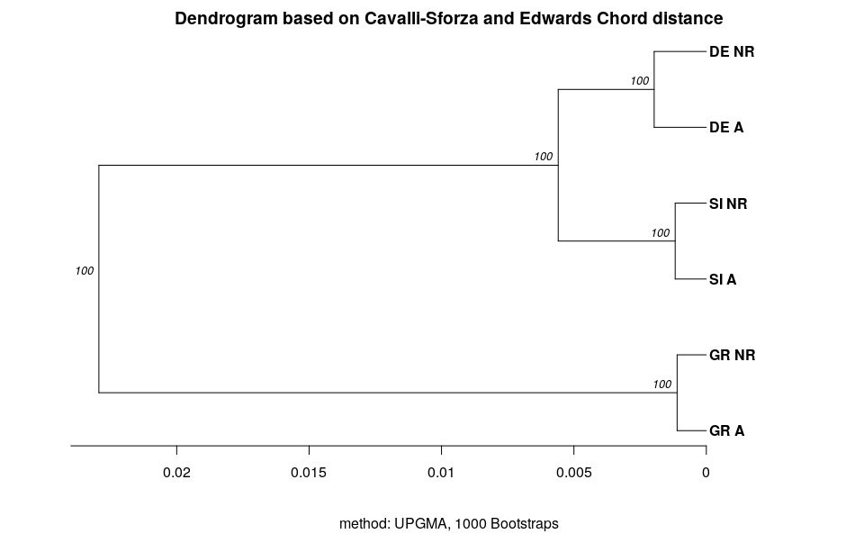

### Nei distance (Nei 1978)

Nei's Standard genetic distance between populations

|  | DE_A | DE_NR | GR_A | GR_NR | SI_A |
| --- | --- | --- | --- | --- | --- |
| DE_NR | 0.0044 |  |  |  |  |
| GR_A | 0.0626 | 0.0679 |  |  |  |
| GR_NR | 0.0652 | 0.0700 | 0.0021 |  |  |
| SI_A | 0.0088 | 0.0106 | 0.0641 | 0.0677 |  |
| SI_NR | 0.0118 | 0.0134 | 0.0639 | 0.0677 | 0.0022 |

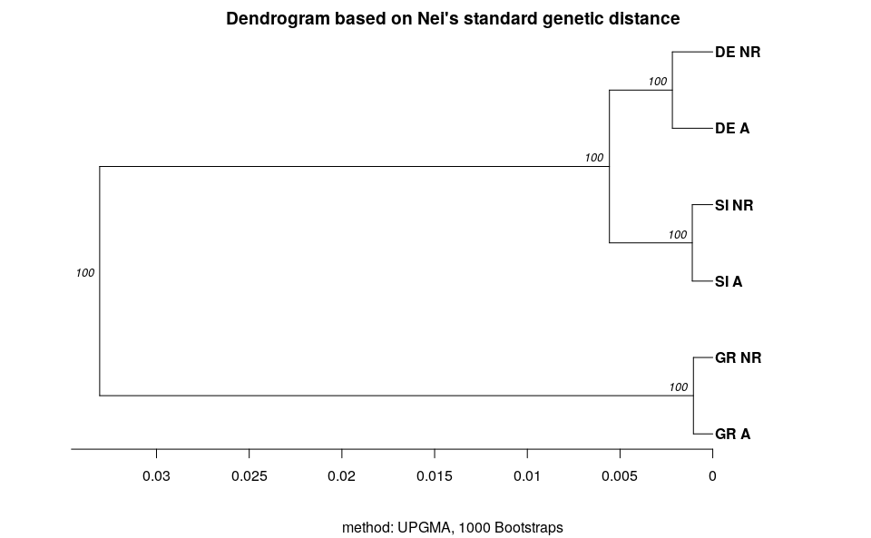

### Principal Component Analysis (PCA)

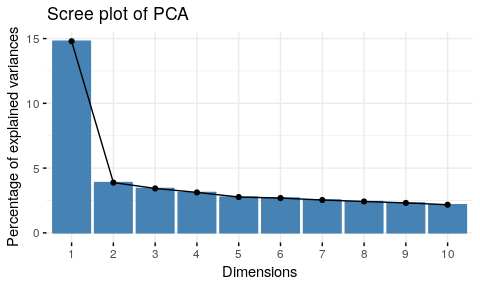

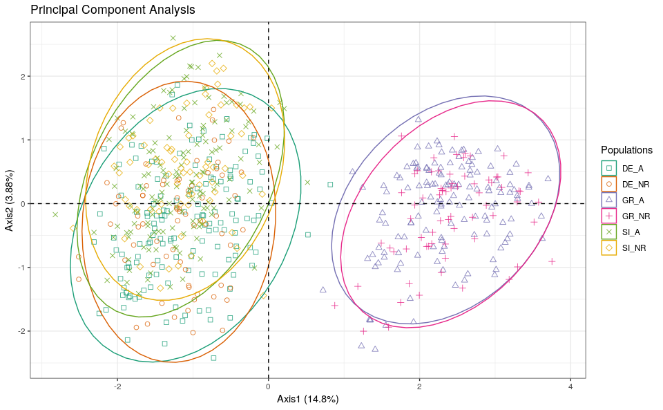

### Correspondence Analysis

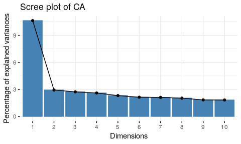

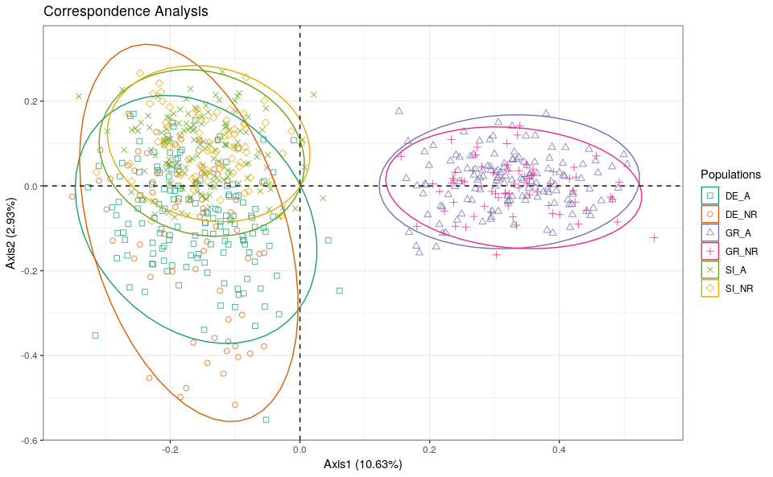

### AMOVA

```
Found 1448 missing values.

2 loci contained missing values greater than 5%

Removing 2 loci: 60_262, 51_2_937
Zero distance(s)Distance matrix is non-euclidean.
Using quasieuclid correction method. See ?quasieuclid for details.
Zero distance(s)Zero distance(s)
```

```
$call
ade4::amova(samples = xtab, distances = xdist, structures = xstruct)

$results
                 Df    Sum Sq   Mean Sq
Between samples   2  1936.402 968.20098
Within samples  642 11539.078  17.97364
Total           644 13475.480  20.92466

$componentsofcovariance
                                Sigma         %
Variations  Between samples  4.420523  19.73962
Variations  Within samples  17.973641  80.26038
Total variations            22.394164 100.00000

$statphi
                        Phi
Phi-samples-total 0.1973962
```

### Hierarchical AMOVA

```
Found 1448 missing values.

2 loci contained missing values greater than 5%

Removing 2 loci: 60_262, 51_2_937
Zero distance(s)Distance matrix is non-euclidean.
Using quasieuclid correction method. See ?quasieuclid for details.
Zero distance(s)Zero distance(s)
```

```
$call
ade4::amova(samples = xtab, distances = xdist, structures = xstruct)

$results
                                Df      Sum Sq   Mean Sq
Between Country                  2  1936.40196 968.20098
Between samples Within Country   3    85.76245  28.58748
Within samples                 639 11453.31533  17.92381
Total                          644 13475.47974  20.92466

$componentsofcovariance
                                                Sigma           %
Variations  Between Country                 4.3584943  19.4626330
Variations  Between samples Within Country  0.1118603   0.4995065
Variations  Within samples                 17.9238112  80.0378605
Total variations                           22.3941658 100.0000000

$statphi
                            Phi
Phi-samples-total   0.199621395
Phi-samples-Country 0.006202171
Phi-Country-total   0.194626330
```

### Hierarchical AMOVA - within variation included (as calculated using Arlequin)

```
Found 1448 missing values.

2 loci contained missing values greater than 5%

Removing 2 loci: 60_262, 51_2_937
Zero distance(s)Distance matrix is non-euclidean.
Using quasieuclid correction method. See ?quasieuclid for details.
Zero distance(s)
```

```
$call
ade4::amova(samples = xtab, distances = xdist, structures = xstruct)

$results
                             Df     Sum Sq    Mean Sq
Between Country               2  3879.8385 1939.91925
Between Pop Within Country    3   170.4175   56.80582
Between samples Within Pop  639 22527.3649   35.25409
Within samples              645 22500.5338   34.88455
Total                      1289 49078.1546   38.07460

$componentsofcovariance
                                            Sigma           %
Variations  Between Country             4.3674012  11.0428010
Variations  Between Pop Within Country  0.1130372   0.2858100
Variations  Between samples Within Pop  0.1847718   0.4671883
Variations  Within samples             34.8845485  88.2042007
Total variations                       39.5497587 100.0000000

$statphi
                          Phi
Phi-samples-total 0.117957993
Phi-samples-Pop   0.005268760
Phi-Pop-Country   0.003212894
Phi-Country-total 0.110428010
```

### IBD

```
NAs introduced by coercion
```

```
Monte-Carlo test
Call: mantel.randtest(m1 = Dgen, m2 = Dgeo)

Observation: 0.9925633

Based on 999 replicates
Simulated p-value: 0.154
Alternative hypothesis: greater

    Std.Obs Expectation    Variance
 1.43948715 -0.01407949  0.48902965
```

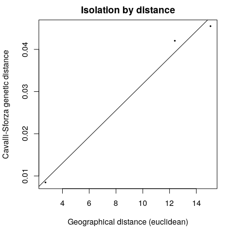

# Effective Population Size (Ne) estimation

Estimate Ne from linkage disequilibrium based on Pearson correlation approximation following (Waples, Larson, and Waples 2016).

## Effective Population Size (Ne)

Effective Population Size - Maf=0.01

| population | S | num.comp | mean.rsq | mean.E.rsq | Ne | param.lci | param.uci |
| --- | --- | --- | --- | --- | --- | --- | --- |
| DE_A | 146 | 3240 | 0.015 | 0.007 | 39.981 | 36.301 | 44.088 |
| DE_NR | 72 | 3486 | 0.027 | 0.015 | 24.134 | 21.610 | 27.005 |
| GR_A | 139 | 903 | 0.014 | 0.007 | 51.408 | 41.865 | 63.837 |
| GR_NR | 70 | 2775 | 0.025 | 0.015 | 32.121 | 27.907 | 37.202 |
| SI_A | 146 | 2556 | 0.012 | 0.007 | 60.217 | 52.933 | 68.856 |
| SI_NR | 72 | 2628 | 0.023 | 0.015 | 38.810 | 33.230 | 45.759 |

Effective Population Size - Maf=0.05

| population | S | num.comp | mean.rsq | mean.E.rsq | Ne | param.lci | param.uci |
| --- | --- | --- | --- | --- | --- | --- | --- |
| DE_A | 146 | 2080 | 0.017 | 0.007 | 32.079 | 28.676 | 35.902 |
| DE_NR | 72 | 2211 | 0.032 | 0.015 | 16.364 | 14.431 | 18.541 |
| GR_A | 139 | 496 | 0.014 | 0.007 | 50.502 | 38.427 | 67.688 |
| GR_NR | 70 | 1891 | 0.028 | 0.015 | 23.688 | 20.370 | 27.650 |
| SI_A | 146 | 1653 | 0.014 | 0.007 | 48.278 | 41.763 | 56.061 |
| SI_NR | 72 | 1953 | 0.024 | 0.015 | 32.808 | 27.793 | 39.064 |

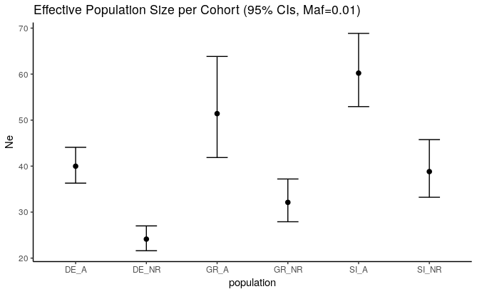

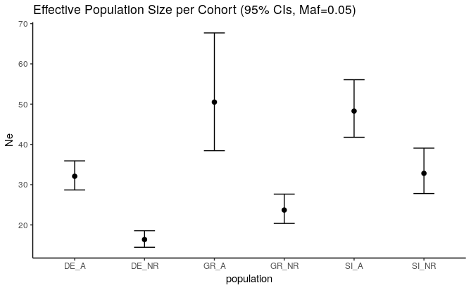

## Effective Population Size (Ne) estimation after removal of SNPs in LD

Effective Population Size - Maf=0.01

| population | S | num.comp | mean.rsq | mean.E.rsq | Ne | param.lci | param.uci |
| --- | --- | --- | --- | --- | --- | --- | --- |
| DE_A | 146 | 2080 | 0.011 | 0.007 | 91.474 | 76.601 | 110.960 |
| DE_NR | 72 | 2145 | 0.023 | 0.015 | 36.401 | 30.829 | 43.415 |
| GR_A | 139 | 595 | 0.011 | 0.007 | 97.557 | 69.200 | 147.713 |
| GR_NR | 70 | 1653 | 0.021 | 0.015 | 52.445 | 41.585 | 68.172 |
| SI_A | 146 | 1830 | 0.009 | 0.007 | 174.634 | 131.704 | 247.153 |
| SI_NR | 72 | 1830 | 0.018 | 0.015 | 92.490 | 68.027 | 136.211 |

Effective Population Size - Maf=0.05

| population | S | num.comp | mean.rsq | mean.E.rsq | Ne | param.lci | param.uci |
| --- | --- | --- | --- | --- | --- | --- | --- |
| DE_A | 146 | 1225 | 0.011 | 0.007 | 82.956 | 66.779 | 105.330 |
| DE_NR | 72 | 1176 | 0.027 | 0.015 | 23.634 | 19.582 | 28.679 |
| GR_A | 139 | 325 | 0.009 | 0.007 | 180.263 | 95.297 | 588.775 |
| GR_NR | 70 | 1035 | 0.023 | 0.015 | 41.213 | 31.924 | 54.800 |
| SI_A | 146 | 1128 | 0.009 | 0.007 | 146.899 | 107.199 | 217.222 |
| SI_NR | 72 | 1275 | 0.018 | 0.015 | 92.514 | 64.423 | 149.346 |

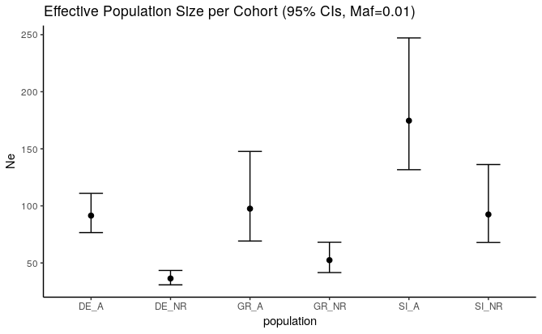

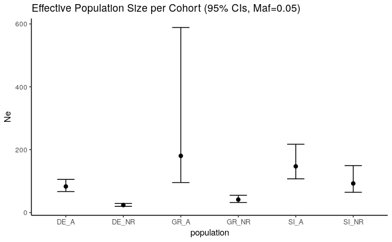

# Reproducibility

|  | setting | value |
| --- | --- | --- |
| version | version | R version 3.6.0 (2019-04-26) |
| os | os | Debian GNU/Linux 9 (stretch) |
| system | system | x86_64, linux-gnu |
| ui | ui | RStudio |
| language | language | (EN) |
| collate | collate | en_US.UTF-8 |
| ctype | ctype | en_US.UTF-8 |
| tz | tz | Etc/UTC |
| date | date | 2019-06-30 |

# Bibliography

Cavalli Sforza, Luigi L., and Anthony WF Edwards. 1967. “Phylogenetic Analysis: Models and Estimation Procedures.” *Evolution* 21 (3): 550–70.

Nei, M. 1978. “Estimation of Average Heterozygosity and Genetic Distance from a Small Number of Individuals.” *Genetics* 89 (3): 583–90. https://doi.org/10.3390/ijms15010277.

Nei, Masatoshi. 1987. *Molecular Evolutionary Genetics*. New York: Columbia university press.

Waples, R K, W A Larson, and R S Waples. 2016. “Estimating Contemporary Effective Population Size in Non-Model Species Using Linkage Disequilibrium Across Thousands of Loci.” *Heredity* 117 (4): 233–40. https://doi.org/10.1038/hdy.2016.60.